# Investigating sQTL analysis results of interest: an overview

We've got 5 introns having 3 QTLs, 3 having 4 QTLs and 2 having 5 QTLs. This notebook shows SuSiE plots for these cases as an overview and a search for interesting patterns to look into.

```python
%cd /project/compbio/jointLCLs/results/SuSiE/fastqtl_qqnorm_ASintron_RNAseqGeuvadis_YangVCF_100Kb
```

```
/project/compbio/jointLCLs/results/SuSiE/fastqtl_qqnorm_ASintron_RNAseqGeuvadis_YangVCF_100Kb
```

## 5 QTL case

For the example below, it is interesting we see more independent signals than we would otherwise mistakenly thought of as results of LD.

%preview SuSiE_CS_5/AS_chr12_27542229_27543041_clu_562.png

> SuSiE_CS_5/AS_chr12_27542229_27543041_clu_562.png (196.3 KiB):

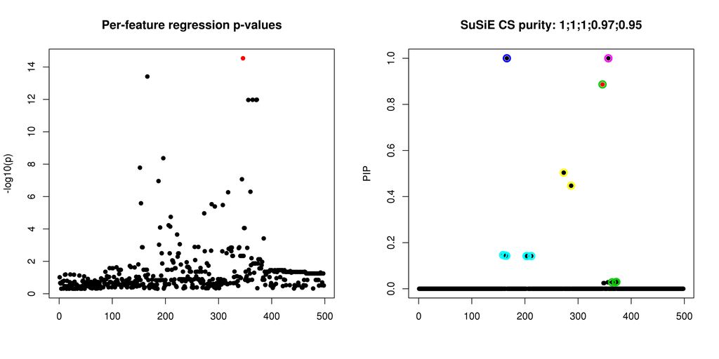

```python
%preview SuSiE_CS_5/AS_chr12_27542229_27543041_clu_562.png
```

The case below looks like a borderline at the face value, but the purity is suprisingly high.

%preview SuSiE_CS_5/AS_chr7_43695752_43696815_clu_10066.png

> SuSiE_CS_5/AS_chr7_43695752_43696815_clu_10066.png (217.1 KiB):

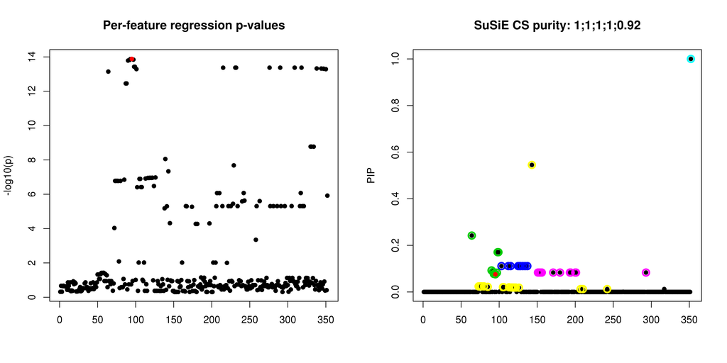

```python
%preview SuSiE_CS_5/AS_chr7_43695752_43696815_clu_10066.png
```

## 4 QTL case

Notice that below is the same intron cluster as the 5 QTL case above. It has perfectly correlated signals. The top z-score has PIP zero.

%preview SuSiE_CS_4/AS_chr12_27542229_27543032_clu_562.png

> SuSiE_CS_4/AS_chr12_27542229_27543032_clu_562.png (180.2 KiB):

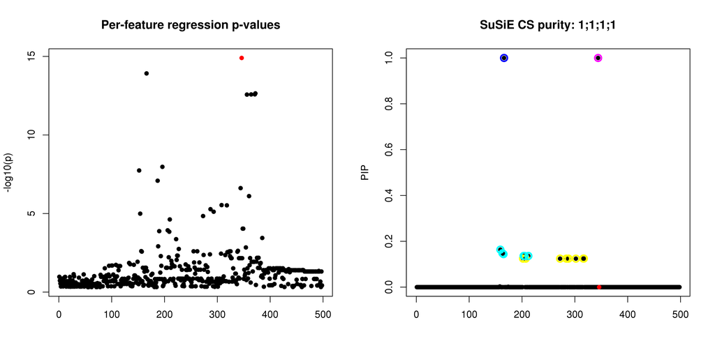

```python
%preview SuSiE_CS_4/AS_chr12_27542229_27543032_clu_562.png
```

This case looks interesting. Is this a borderline case, or does it indeed have more signals?

%preview SuSiE_CS_4/AS_chr15_80253516_80263042_clu_6186.png

> SuSiE_CS_4/AS_chr15_80253516_80263042_clu_6186.png (211.0 KiB):

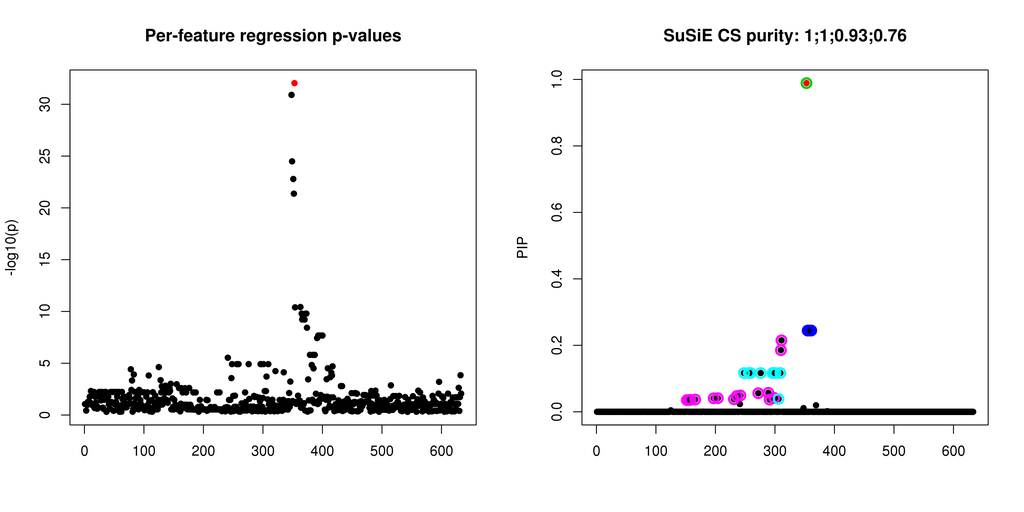

```python
%preview SuSiE_CS_4/AS_chr15_80253516_80263042_clu_6186.png
```

This is an interesting case where the top signal from z-score was kept yet SuSiE distinctly reports a secondary signal that otherwise will be missed by looking at z-score plot.

%preview SuSiE_CS_4/AS_chr7_75687396_75692833_clu_10233.png

> SuSiE_CS_4/AS_chr7_75687396_75692833_clu_10233.png (210.9 KiB):

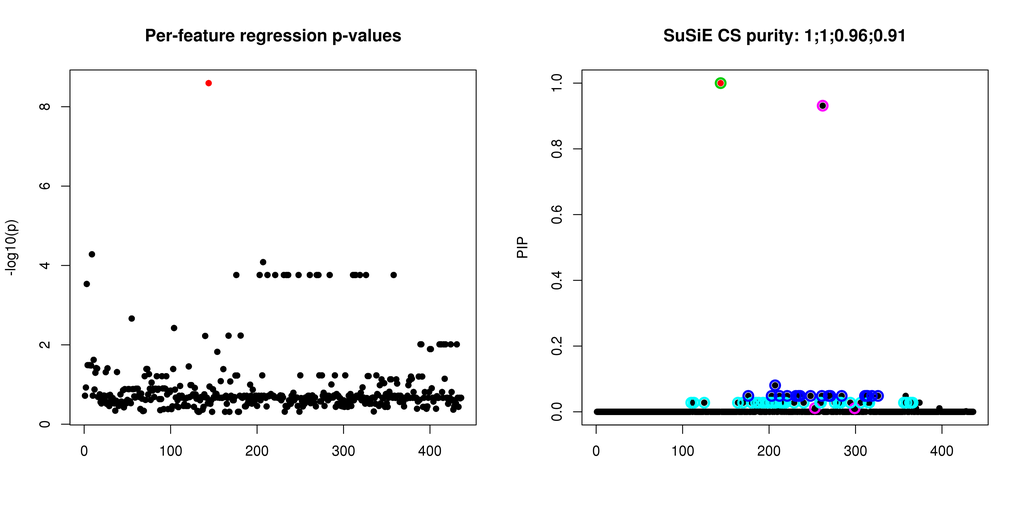

```python
%preview SuSiE_CS_4/AS_chr7_75687396_75692833_clu_10233.png
```

## 3 QTL case

Seems like a case of pure additional discovery.

%preview SuSiE_CS_3/AS_chr12_113355505_113357292_clu_1224.png

> SuSiE_CS_3/AS_chr12_113355505_113357292_clu_1224.png (188.4 KiB):

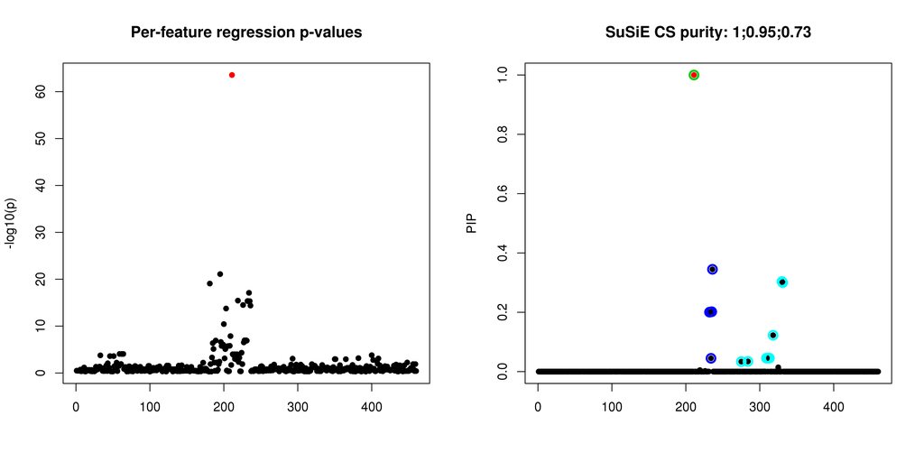

```python
%preview SuSiE_CS_3/AS_chr12_113355505_113357292_clu_1224.png
```

I wonder what happened to the 3rd dot on the left panel ... is SuSiE acting up?

%preview SuSiE_CS_3/AS_chr14_20813285_20813553_clu_6322.png

> SuSiE_CS_3/AS_chr14_20813285_20813553_clu_6322.png (158.8 KiB):

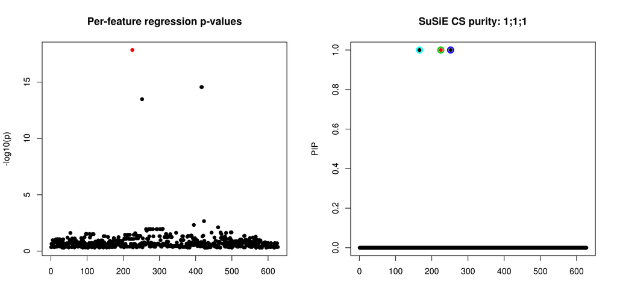

```python
%preview SuSiE_CS_3/AS_chr14_20813285_20813553_clu_6322.png
```

Nothing much to say here ... the one with purity 0.45 looks interesting, though.

%preview SuSiE_CS_3/AS_chr4_40236978_40244334_clu_12620.png

> SuSiE_CS_3/AS_chr4_40236978_40244334_clu_12620.png (190.4 KiB):

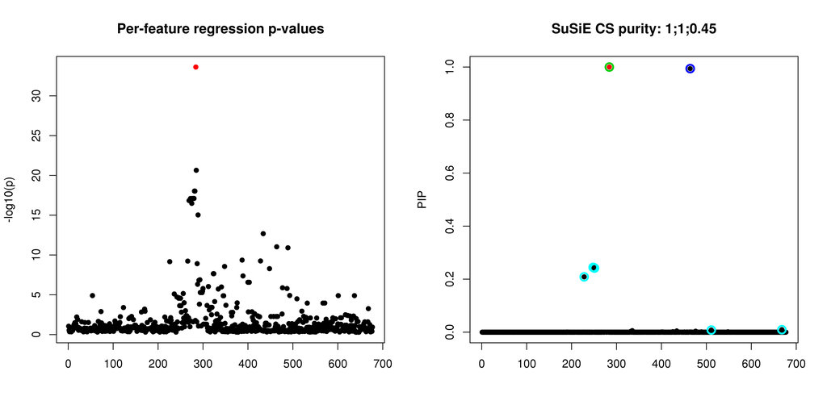

```python
%preview SuSiE_CS_3/AS_chr4_40236978_40244334_clu_12620.png
```

Also a very interesting case. I wonder why no secondary signal showed up in the z-score space.

%preview SuSiE_CS_3/AS_chr7_137600758_137612896_clu_10520.png

> SuSiE_CS_3/AS_chr7_137600758_137612896_clu_10520.png (193.3 KiB):

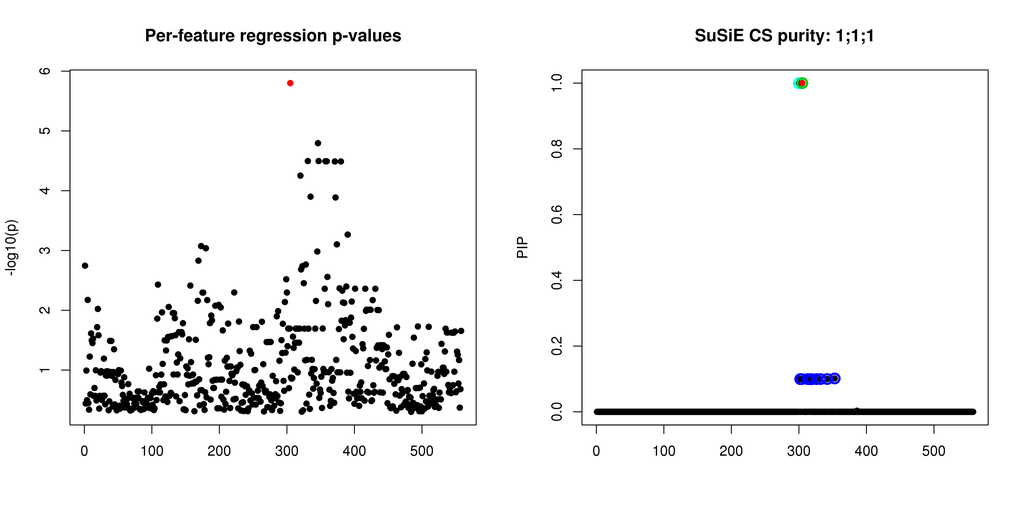

```python
%preview SuSiE_CS_3/AS_chr7_137600758_137612896_clu_10520.png
```

Notice that example below locates nearby to the example above.

%preview SuSiE_CS_3/AS_chr7_140404763_140421352_clu_10535.png

> SuSiE_CS_3/AS_chr7_140404763_140421352_clu_10535.png (169.2 KiB):

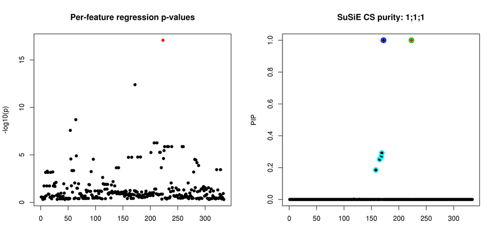

```python
%preview SuSiE_CS_3/AS_chr7_140404763_140421352_clu_10535.png
```

Copyright © 2016-2020 Gao Wang et al at Stephens Lab, University of Chicago